# assignmentPS5

Maansi Surve

2023-02-17

R Markdown

## ——————— 1.) Load and check data (5pt)

You first task is to do a very simple data check:

1. (1pt) For solving the problems, and answering the questions, create a new rmarkdown document with an appropriate title. See https://faculty.washington.edu/otoomet/info201-book/r-markdown.html#r-markdown-rstudio-creating
2. (2pt) Load data. How many rows/columns do we have?

```r
  library(tidyverse)
  library(readr)
  library(ggplot2)
  library(dplyr)
  file <- read_delim("gapminder.csv")
```

These are the dimensions of the **GapMinder** file.

```r
  file %>%
    dim()
```

```
## [1] 13055    25
```

3. (2pt) Print a small sample of data. Does it look OK?

```r
  file %>%
    sample_n(5)
```

```
## # A tibble: 5 × 25
##   iso3  name  iso2  region sub-r…¹ inter…²  time total…³ ferti…⁴ lifeE…⁵ child…⁶
##   <chr> <chr> <chr> <chr>  <chr>   <chr>   <dbl>   <dbl>   <dbl>   <dbl>   <dbl>
## 1 MYS   Mala… MY    Asia   South-… <NA>     1998  2.21e7    3.04    72.3    11.7
## 2 IRL   Irel… IE    Europe Northe… <NA>     1990  3.51e6    2.11    74.8     9.2
## 3 RWA   Rwan… RW    Africa Sub-Sa… Easter…  1960  2.94e6    8.19    42.6   221.
## 4 MDG   Mada… MG    Africa Sub-Sa… Easter…  2003  1.73e7    5.24    60.3    92.5
## 5 FIN   Finl… FI    Europe Northe… <NA>     2004  5.23e6    1.8     78.7     3.9
## # … with 14 more variables: youthFemaleLiteracy <dbl>, youthMaleLiteracy <dbl>,
## #   adultLiteracy <dbl>, GDP_PC <dbl>, accessElectricity <dbl>,
## #   agriculturalLand <dbl>, agricultureTractors <dbl>, cerealProduction <dbl>,
## #   fertilizerHa <dbl>, co2 <dbl>, greenhouseGases <dbl>, co2_PC <dbl>,
## #   pm2.5_35 <dbl>, battleDeaths <dbl>, and abbreviated variable names
## #   ¹`sub-region`, ²`intermediate-region`, ³totalPopulation, ⁴fertilityRate,
## #   ⁵lifeExpectancy, ⁶childMortality
```

**The data looks OK.**

## ——————— 2 Descriptive statistics (15pt)

1. (3pt) How many countries are there in the dataset? Analyze all three: iso3, iso2 and name.

There are this many **countries** in the dataset, categorized by *iso3 code, iso2 code,* & *name*:

```r
file %>%
  summarize(uniqueByIso3 = n_distinct(iso3), uniqueByIso2 = n_distinct(iso2),
            uniqueByName = n_distinct(name))
```

```
## # A tibble: 1 × 3
##   uniqueByIso3 uniqueByIso2 uniqueByName
##          <int>        <int>        <int>
## 1          253          249          250
```

2. If you did this correctly, you saw that there are more names than iso-2 codes, and there are even more iso3 -codes. What is going on? Can you find it out?

*There are NA values or empty values being accounted for, which is messing up the numbers.*

```
    (a) (5pt) Find how many names are there for each iso-2 code. Are there any iso-2 codes that
    correspond to more than one name? What are these countries?
```

```r
file %>%
  group_by(iso2)  %>%
  summarize(num = n_distinct(name)) %>%
  arrange(desc(num))
```

```
## # A tibble: 249 × 2
##    iso2    num
##    <chr> <int>
##  1 <NA>      2
##  2 AD        1
##  3 AE        1
##  4 AF        1
##  5 AG        1
##  6 AI        1
##  7 AL        1
##  8 AM        1
##  9 AO        1
## 10 AQ        1
## # … with 239 more rows
```

There are iso2 codes that correspond to more than one name. It is the code “NA”.

```
    (b) (5pt) Now repeat the same for name and iso3-code. Are there country names that have
    more than one iso3-code? What are these countries?
    Hint: two of these entities are CHANISL and NLD CURACAO.
```

```r
file %>%
  group_by(name)  %>%
  summarize(num = n_distinct(iso3)) %>%
  arrange(desc(num))
```

```
## # A tibble: 250 × 2
##    name                  num
##    <chr>               <int>
##  1 <NA>                    4
##  2 Afghanistan             1
##  3 Albania                 1
##  4 Algeria                 1
##  5 American Samoa          1
##  6 Andorra                 1
##  7 Angola                  1
##  8 Anguilla                1
##  9 Antarctica              1
## 10 Antigua and Barbuda     1
## # … with 240 more rows
```

There are names that correspond to more than one iso3 code. It is the name “NA”.

3. (2pt) What is the minimum and maximum year in these data?

These are the **minimum** and **maximum** years in the data:

```r
  file %>%
    filter(!is.na(time)) %>%
    summarize(minYear = min(time), maxYear = max(time))
```

```
## # A tibble: 1 × 2
##   minYear maxYear
##     <dbl>   <dbl>
## 1    1960    2019
```

## ——————— 3 CO2 emissions (30pt)

Next, let’s analyze CO2 emissions. 1. (2pt) How many missing co2 emissions are there for each year? Analyze both missing CO2 and co2_PC. Which years have most missing data?

Here is the amount of *missing CO2 emissions per year*, as well as the **Top 10 years** missing the most data:

```r
missingCO2 <- file %>%
  group_by(time) %>%
  summarize(total = sum(is.na(co2))) %>%
  arrange(rank(desc(total)))

missingCO2 %>%
  top_n(10)
```

```
## # A tibble: 13 × 2
##     time total
##    <dbl> <int>
##  1  2017   217
##  2  2018   217
##  3  2019   217
##  4  1960    60
##  5  1961    60
##  6  1962    58
##  7  1963    57
##  8  1964    51
##  9  1965    51
## 10  1966    51
## 11  1967    51
## 12  1968    51
## 13  1969    51
```

Here is the amount of *missing CO2 emissions per capita per year*, as well as the **Top 10 years** missing the most data:

```r
missingCO2_PC <- file %>%
  group_by(time) %>%
  summarize(total = sum(is.na(co2_PC))) %>%
  arrange(rank(desc(total)))

missingCO2_PC %>%
  top_n(10)
```

```
## # A tibble: 13 × 2
##     time total
##    <dbl> <int>
##  1  2017   217
##  2  2018   217
##  3  2019   217
##  4  1960    60
##  5  1961    60
##  6  1962    58
##  7  1963    57
##  8  1964    51
##  9  1965    51
## 10  1966    51
## 11  1967    51
## 12  1968    51
## 13  1969    51
```

2. (5pt) Make a plot of total CO2 emissions over time for the U.S, China, and India. Add a few more countries of your choice. Explain what do you see.

This plot shows the *total CO2 emissions over time* by country for the U.S., China, India, Aruba, and Angola:

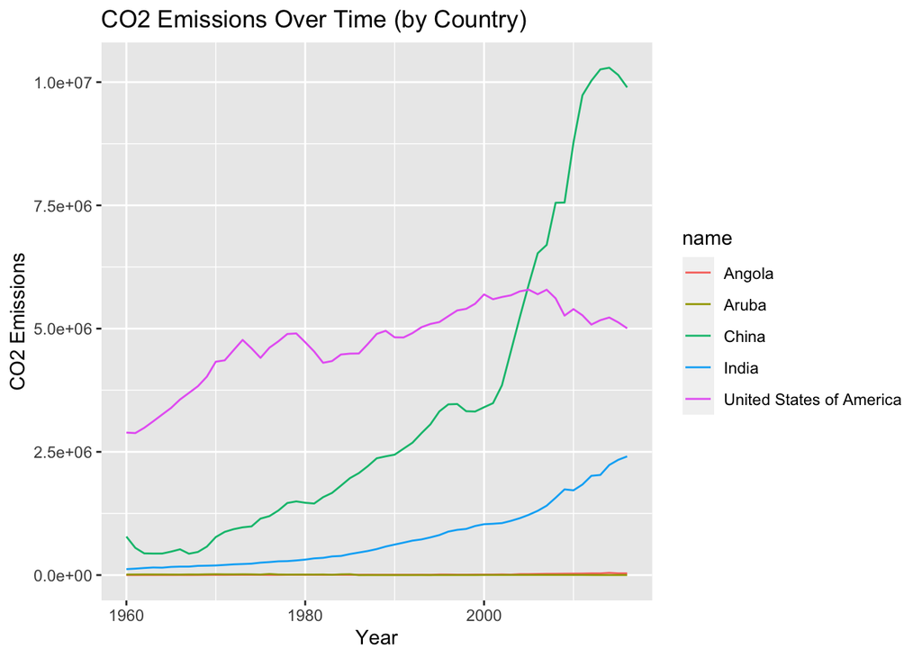

```r
overtime <- file %>%
  filter(name == "China" | name == "India" | name == "United States of America" | name == "Aruba" | name == "Angola", !is.na(co2), !is.na(name)) %>%
  select(name, time, co2) %>%
  group_by(time)

ggplot(overtime, aes(x = time, y = co2, col = name)) +
  geom_line() +
  xlab("Year") +
  ylab("CO2 Emissions") +
  ggtitle("CO2 Emissions Over Time (by Country)")
```

The graph shows that for all countries, except for Aruba and Angola, CO2 emissions have increased drastically over the years. India is still increasing, but the U.S. and China’s emissions are going down. Aruba and Angola have little emissions and their growth is almost non-existent.

3. (5pt) Now let’s analyze the CO2 emissions per capita (co2_PC ). Make a similar plot of the same countries. What does this figure suggest?

This plot shows the *total CO2 emissions per capita over time* for the U.S., China, India, Aruba, and Angola:

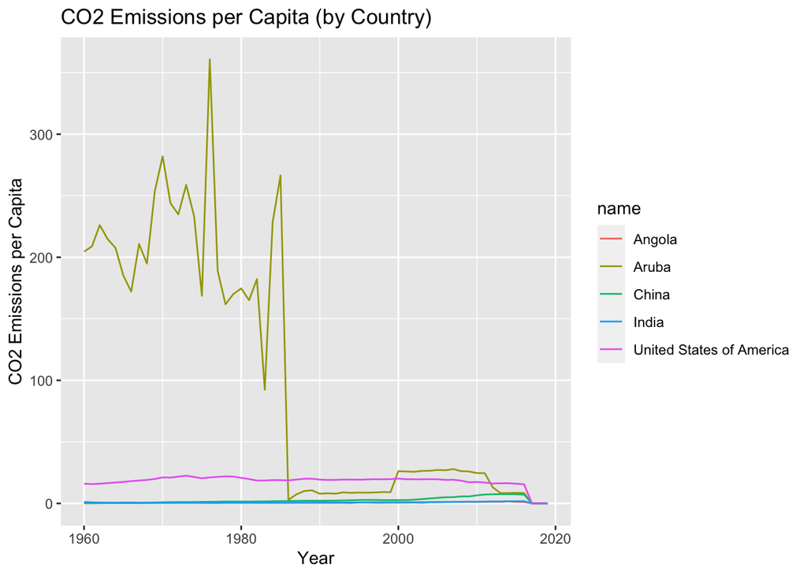

```r
by_country <- file %>%
  filter(name == "China" | name == "India" | name == "United States of America" | name == "Aruba" | name == "Angola") %>%
  group_by(name, time) %>%
  summarize(co2_pc = sum(co2_PC, na.rm=TRUE))

ggplot(by_country, aes(x = time, y = co2_pc, col = name)) +
    geom_line() +
    xlab("Year") +
    ylab("CO2 Emissions per Capita") +
    ggtitle("CO2 Emissions per Capita (by Country)")
```

The figure suggests that overtime, the CO2 per capita emissions increased drastically in Aruba but then drastically dropped, but for the other countries the CO2 per capita emissions have been steady over the years.

4. (6pt) Compute average CO2 emissions per capita across the continents (assume region is the same as continent). Comment what do you see. Note: just compute averages over countries and ignore the fact that countries are of different size. Hint: Americas 2016 should be 4.80.

```r
file %>%
  filter(time %in% c(1960, 2016), !is.na(region), !is.na(co2_PC)) %>%
  group_by(time, region) %>%
  summarize(avgCO2_PC = mean(co2_PC))
```

```
## # A tibble: 10 × 3
## # Groups:   time [2]
##     time region   avgCO2_PC
##    <dbl> <chr>        <dbl>
##  1  1960 Africa       0.291
##  2  1960 Americas     7.15
##  3  1960 Asia         1.74
##  4  1960 Europe       5.77
##  5  1960 Oceania      2.73
##  6  2016 Africa       1.20
##  7  2016 Americas     4.80
##  8  2016 Asia         6.47
##  9  2016 Europe       6.64
## 10  2016 Oceania      4.57
```

The data suggests that average CO2 emissions per capita across the continents increased over the years, from 1960 to 2016, except for the Americas, for which it decreased. For some regions it increased drastically, for example, Asia.

5. (7pt) Make a barplot where you show the previous results–average CO2 emissions per capita across continents in 1960 and 2016. Hint: it should look something along these lines:

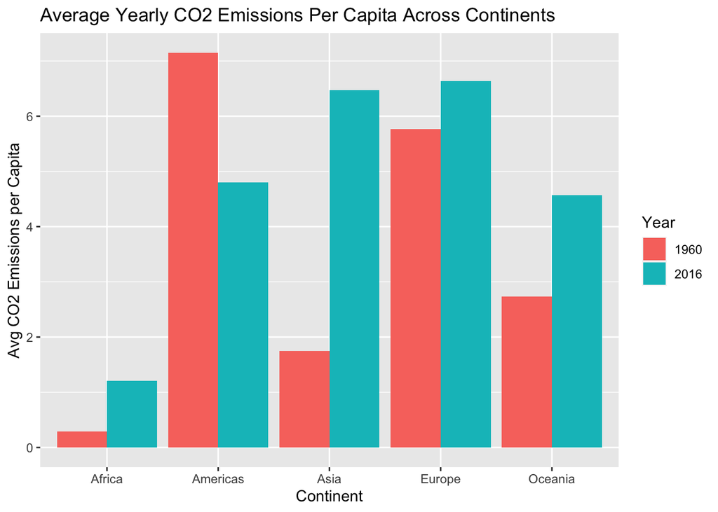

```r
file %>%
  filter(time %in% c(1960, 2016), !is.na(region), !is.na(co2_PC)) %>%
  group_by(time, region) %>%
  summarize(avgCO2_PC = mean(co2_PC)) %>%
  ggplot(aes(x = region, y = avgCO2_PC, fill=factor(time))) +
  geom_col(position = "dodge") +
    labs(title = "Average Yearly CO2 Emissions Per Capita Across Continents",
         x = "Continent", y = "Avg CO2 Emissions per Capita") +
    scale_fill_discrete(name = "Year")
```

The bar graph suggests that most regions in 2016 had more yearly CO2 emissions per capita than in 1960, except for Americas.

6. Which countries are the three largest, and three smallest CO2 emitters (in terms of CO2 per capita) in 2019 for each continent? (Assume region is continent).

**NOTE: I went with 2016 since 2019 data is insufficient.**

These are the three **largest** CO2 emitting countries in each continent:

```r
file %>%
  filter(!is.na(co2_PC), !is.na(name),!is.na(region), time == "2016") %>%
  group_by(region, name) %>%
  summarize(avg_CO2 = mean(co2_PC)) %>%
  arrange(rank(desc(region))) %>%
  group_by(region) %>%
  select(region, name, avg_CO2) %>%
  top_n(3)
```

```
## # A tibble: 15 × 3
## # Groups:   region [5]
##    region   name                     avg_CO2
##    <chr>    <chr>                      <dbl>
##  1 Oceania  Australia                  15.5
##  2 Oceania  New Caledonia              19.3
##  3 Oceania  Palau                      12.6
##  4 Europe   Faroe Islands              13.1
##  5 Europe   Gibraltar                  18.8
##  6 Europe   Luxembourg                 15.4
##  7 Asia     Bahrain                    22.2
##  8 Asia     Kuwait                     25.0
##  9 Asia     Qatar                      38.9
## 10 Americas Canada                     15.1
## 11 Americas Trinidad and Tobago        31.8
## 12 Americas United States of America   15.5
## 13 Africa   Libya                       7.79
## 14 Africa   Seychelles                  6.39
## 15 Africa   South Africa                8.48
```

These are the three **smallest** CO2 emitting countries in each continent:

```r
file %>%
  filter(!is.na(co2_PC), !is.na(name),!is.na(region), time == "2016") %>%
  group_by(region, name) %>%
  summarize(avg_CO2 = mean(co2_PC)) %>%
  arrange(rank(desc(region))) %>%
  group_by(region) %>%
  select(region, name, avg_CO2) %>%
  top_n(-3)
```

```
## # A tibble: 15 × 3
## # Groups:   region [5]
##    region   name                              avg_CO2
##    <chr>    <chr>                               <dbl>
##  1 Oceania  Kiribati                           0.587
##  2 Oceania  Solomon Islands                    0.272
##  3 Oceania  Vanuatu                            0.527
##  4 Europe   Albania                            1.58
##  5 Europe   Liechtenstein                      1.36
##  6 Europe   Moldova, Republic of               1.83
##  7 Asia     Afghanistan                        0.245
##  8 Asia     Nepal                              0.334
##  9 Asia     Yemen                              0.390
## 10 Americas Haiti                              0.275
## 11 Americas Honduras                           1.06
## 12 Americas Nicaragua                          0.887
## 13 Africa   Burundi                            0.0472
## 14 Africa   Congo, Democratic Republic of the  0.0256
## 15 Africa   Somalia                            0.0455
```

## ——————— 4 GDP per capita (50pt)

Let’s look at GDP per capita (GDP_PC ).

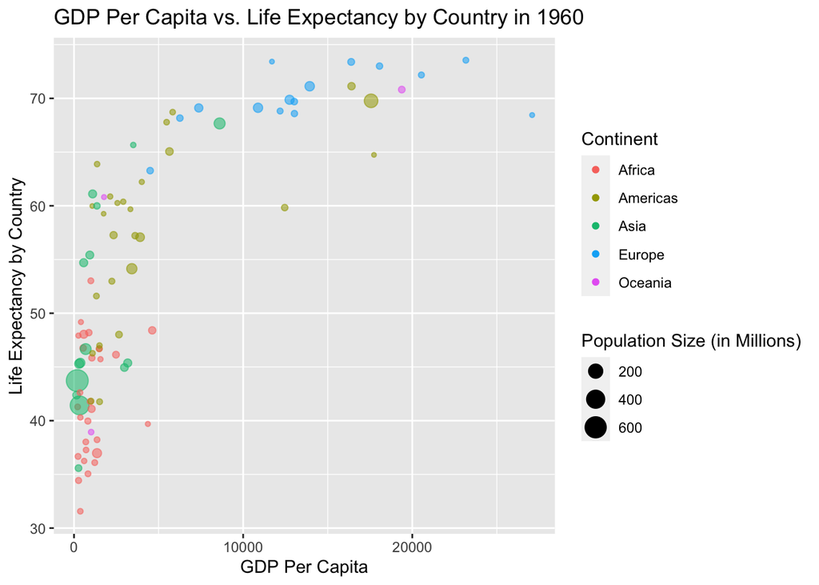

```r
variables <- file %>%
  filter(time == 1960, !is.na(GDP_PC), !is.na(lifeExpectancy)) %>%
  group_by(GDP_PC, lifeExpectancy) %>%
  summarize(x = GDP_PC, y = lifeExpectancy, z = region, a = totalPopulation/1000000)

ggplot(variables, aes(x = GDP_PC, y = lifeExpectancy)) +
   geom_point(aes(color = z, size = a, alpha = 0.5)) +
  labs(title = "GDP Per Capita vs. Life Expectancy by Country in 1960",
         x = "GDP Per Capita", y = "Life Expectancy by Country") +
         guides(color = guide_legend(title = "Continent"), size = guide_legend(title = "Population Size (in Millions)"), alpha = "none")
```

2. (4pt) Make a similar plot, but this time use 2019 data only.

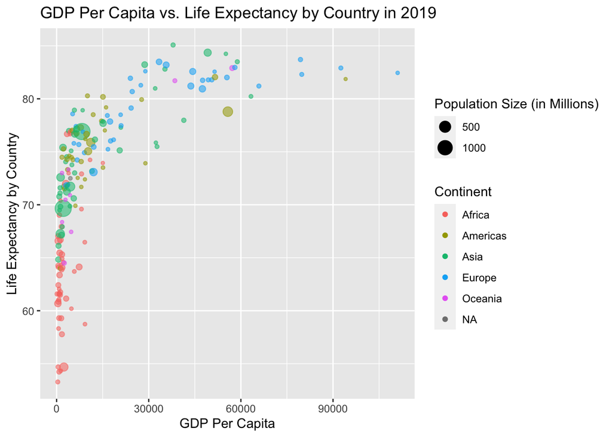

```r
variables <- file %>%
  filter(time == 2019, !is.na(GDP_PC), !is.na(lifeExpectancy)) %>%
  group_by(GDP_PC, lifeExpectancy) %>%
  summarize(x = GDP_PC, y = lifeExpectancy, z = region, a = totalPopulation/1000000)

ggplot(variables, aes(x = GDP_PC, y = lifeExpectancy)) +
   geom_point(aes(color = z, size = a, alpha = 0.5)) +
  labs(title = "GDP Per Capita vs. Life Expectancy by Country in 2019",
         x = "GDP Per Capita", y = "Life Expectancy by Country") +
         guides(color = guide_legend(title = "Continent"), size = guide_legend(title = "Population Size (in Millions)"), alpha = "none")
```

3. (6pt) Compare these two plots and comment what do you see. How has world developed through the last 60 years? Through the last 60 years, life expectancy has increased by a lot. Of course, it can’t constantly be increasing since there’s a limit to how long a human can realistically live. The overall GDP per capita has also increased over the years. Both graphs show similar trends in the data across the different countries and continents.
4. (6pt) Compute the average life expectancy for each continent in 1960 and 2019. Do the results fit with what do you see on the figures? Note: here as average I mean just average over countries, ignore the fact that countries are of different size.

   Average life expectancy in **1960** by continent:

```r
file %>%
  group_by(region) %>%
  filter(time == 1960, !is.na(lifeExpectancy), !is.na(region)) %>%
  summarize(avg_lifeExpectancy = mean(lifeExpectancy))
```

```
## # A tibble: 5 × 2
##   region   avg_lifeExpectancy
##   <chr>                 <dbl>
## 1 Africa                 41.5
## 2 Americas               58.6
## 3 Asia                   51.6
## 4 Europe                 68.3
## 5 Oceania                56.4
```

```
Average life expectancy in **2019** by continent:
```

```r
file %>%
  group_by(region) %>%
  filter(time == 2019, !is.na(lifeExpectancy), !is.na(region)) %>%
  summarize(avg_lifeExpectancy = mean(lifeExpectancy))
```

```
## # A tibble: 5 × 2
##   region   avg_lifeExpectancy
##   <chr>                 <dbl>
## 1 Africa                 64.1
## 2 Americas               75.8
## 3 Asia                   74.6
## 4 Europe                 79.4
## 5 Oceania                73.5
```

**Yes**, the results match what I see on the figures. The averages are reasonable, given the data on the graphs.

5. (8pt) Compute the average LE growth from 1960-2019 across the continents. Show the results in the order of growth. Explain what do you see. Hint: these data (data in long form) is not the simplest to compute growth. But you may want to check out the lag() function. And do not forget to group data by continent when using lag(), otherwise your results will be messed up! See https://faculty.washington. edu/otoomet/info201-book/dplyr.html#dplyr-helpers-compute.

   Average LE growth from 1960-2019 across the continents, in order of growth:

```r
file %>%
  group_by(region, time) %>%
  filter(!is.na(lifeExpectancy), !is.na(region), time == 1960 | time == 2019) %>%
  summarize(avgLE = mean(lifeExpectancy)) %>%
  mutate(prev = lag(avgLE, default = 0, order_by = region), growth = avgLE - prev)
```

```
## # A tibble: 10 × 5
## # Groups:   region [5]
##    region    time avgLE  prev growth
##    <chr>    <dbl> <dbl> <dbl>  <dbl>
##  1 Africa    1960  41.5   0     41.5
##  2 Africa    2019  64.1  41.5   22.6
##  3 Americas  1960  58.6   0     58.6
##  4 Americas  2019  75.8  58.6   17.2
##  5 Asia      1960  51.6   0     51.6
##  6 Asia      2019  74.6  51.6   23.0
##  7 Europe    1960  68.3   0     68.3
##  8 Europe    2019  79.4  68.3   11.1
##  9 Oceania   1960  56.4   0     56.4
## 10 Oceania   2019  73.5  56.4   17.1
```

6. (6pt) Show the histogram of GDP per capita for years of 1960 and 2019. Try to put both histograms on the same graph, see how well you can do it!

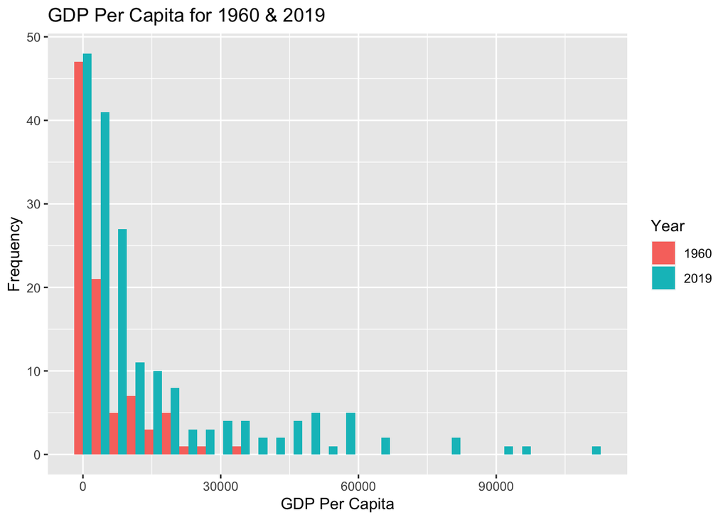

```r
hist <- file %>%
  filter(time == 1960 | time == 2019, !is.na(GDP_PC))

ggplot(hist, aes(x=GDP_PC, fill = as.factor(time)))+
  geom_histogram(position='dodge') +
  guides(fill = guide_legend(title = "Year")) +
  ggtitle("GDP Per Capita for 1960 & 2019") +
  labs(x = "GDP Per Capita", y = "Frequency")
```

7. (6pt) What was the ranking of US in terms of life expectancy in 1960 and in 2019? (When counting from top.) Hint: check out the function rank()! Hint2: 17 for 1960.

The rank of the U.S.’s life expectancy in **1960**:

```r
rank1 <- file %>%
  select(name, time, lifeExpectancy) %>%
  filter(time == 1960, !is.na(lifeExpectancy), name != "") %>%
  arrange(rank(desc(lifeExpectancy))) %>%
  summarize(US_Rank = which(name == "United States of America"))
```

[output not shown]

The rank of the U.S.’s life expectancy in **2019**:

```r
rank2 <- file %>%
  select(name, time, lifeExpectancy) %>%
  filter(time == 2019, !is.na(lifeExpectancy), name != "") %>%
  arrange(rank(desc(lifeExpectancy))) %>%
  summarize(US_Rank = which(name == "United States of America"))
```

[output not shown]

8. (6pt) If you did this correctly, then you noticed that US ranking has been falling quite a bit. But we also have more countries in 2019–what about the relative rank divided by the corresponding number of countries that have LE data in the corresponding year? Hint: 0.0904 for 1960.

The relative rank of the U.S. in **1960**:

```r
file %>%
  filter(time == 1960, !is.na(lifeExpectancy), name != "") %>%
  summarize(numCountries = n_distinct(name), rank = rank1/numCountries)
```

```
## # A tibble: 1 × 2
##   numCountries rank$US_Rank
##          <int>        <dbl>
## 1          188       0.0904
```

```r
file %>%
  filter(time == 2019, !is.na(lifeExpectancy), name != "") %>%
  summarize(numCountries = n_distinct(name), rank = rank1/numCountries)
```

```
## # A tibble: 1 × 2
##   numCountries rank$US_Rank
##          <int>        <dbl>
## 1          196       0.0867
```

9. Finally tell us how many hours did you spend on this PS.

I spent about **16 hours** on this assignment.